# GRIN3D mutation-hotspot stability evaluation

TP53, PTEN, SUZ12, EZH2, and LEF1 trial-depth and AlphaFold pLDDT sensitivity

September 18, 2026

# Purpose

This notebook evaluates whether the GRIN3D mutation-hotspot prototype produces stable candidate clusters when two analysis settings are varied:

1. the number of null simulations (`100` through `1,000` in increments of `100`); and
2. the minimum AlphaFold pLDDT threshold (`0`, `70`, or `90`).

TP53 serves as the established dense positive-control pattern, while PTEN adds an independent mutation-rich tumor suppressor. SUZ12, EZH2, and LEF1 represent sparser mutation patterns across proteins with different lengths and confidence profiles.

Here, **sparsity** is not a single formal label. It can entail fewer mutation events or affected subjects, fewer recurrent observations at the same residue, a low density of altered residues relative to protein length, or mutations that are widely dispersed in sequence or 3D space. These features have different statistical consequences: limited event and subject counts reduce power, weak recurrence makes compact clusters harder to distinguish from random placement, and spatial dispersion can produce many candidate branches without a compelling hotspot. Sparsity also makes confidence filtering more consequential because removing even a modest number of events may represent a large fraction of the analyzed cohort. Accordingly, the sparse-protein results are interpreted using retained events and subjects, cluster membership overlap, and p-value convergence together rather than mutation count alone.

**Primary conclusion.** Null-trial count changes Monte Carlo p-values and significance calls, but not the deterministic observed cluster membership at a fixed pLDDT threshold. pLDDT filtering can change cluster membership because it removes coordinates and mutation events, thereby changing the analyzed cohort.

## Experiment completeness

The expected design is 5 proteins × 3 pLDDT thresholds × 10 trial counts = 150 configurations. This cell confirms that the expected saved result objects exist.

```r
experiment_status <- data.frame(
  Measure = c(
    "Configured runs", "Available result objects", "Available manifests",
    "Trial levels", "pLDDT levels"
  ),
  Value = c(
    nrow(config),
    sum(file.exists(file.path(config$results_dir, "GRIN3D_mutation_hotspot_results.rds"))),
    sum(file.exists(file.path(config$results_dir, "stability_run_manifest.csv"))),
    paste(sort(unique(config$n_sim)), collapse = ", "),
    paste(sort(unique(config$plddt_threshold)), collapse = ", ")
  )
)
display_table(experiment_status)
```

| Measure | Value |
| --- | --- |
| Configured runs | 150 |
| Available result objects | 150 |
| Available manifests | 150 |
| Trial levels | 100, 200, 300, 400, 500, 600, 700, 800, 900, 1000 |
| pLDDT levels | 0, 70, 90 |

# 1 Results at 1,000 trials

This table is the compact numerical summary of the experiment. `Residues` and `Events` show retained/total counts. Mean Jaccard compares each condition’s candidate clusters with the unfiltered 1,000-trial cluster landscape for the same protein.

```r
maximum_results <- run_metrics[run_metrics$n_sim == 1000, ]
maximum_results <- maximum_results[
  order(match(maximum_results$protein, c("TP53", "PTEN", "SUZ12", "EZH2", "LEF1")),
        maximum_results$plddt_threshold),
]

maximum_display <- data.frame(
  Protein = maximum_results$protein,
  pLDDT = maximum_results$plddt_threshold,
  Residues = paste0(maximum_results$eligible_residues, "/", maximum_results$total_coordinate_residues),
  Events = paste0(maximum_results$mapped_events, "/",
                  maximum_results$mapped_events + maximum_results$excluded_events),
  Subjects = maximum_results$mapped_subjects,
  Clusters = maximum_results$n_clusters,
  Significant = maximum_results$n_significant,
  `Mean Jaccard` = maximum_results$mean_best_jaccard,
  `Median Jaccard` = maximum_results$median_best_jaccard,
  check.names = FALSE
)
display_table(maximum_display, caption = "Results at the maximum evaluated trial count")
```

Results at the maximum evaluated trial count

| Protein | pLDDT | Residues | Events | Subjects | Clusters | Significant | Mean Jaccard | Median Jaccard |
| --- | --- | --- | --- | --- | --- | --- | --- | --- |
| TP53 | 0 | 393/393 | 30/30 | 23 | 41 | 11 | 1.000 | 1.000 |
| TP53 | 70 | 235/393 | 26/30 | 20 | 35 | 6 | 0.880 | 1.000 |
| TP53 | 90 | 207/393 | 25/30 | 19 | 33 | 6 | 0.873 | 1.000 |
| PTEN | 0 | 403/403 | 313/313 | 180 | 162 | 0 | 1.000 | 1.000 |
| PTEN | 70 | 313/403 | 309/313 | 177 | 154 | 0 | 0.973 | 1.000 |
| PTEN | 90 | 277/403 | 303/313 | 177 | 149 | 0 | 0.922 | 1.000 |
| SUZ12 | 0 | 739/739 | 72/72 | 57 | 96 | 0 | 1.000 | 1.000 |
| SUZ12 | 70 | 453/739 | 49/72 | 42 | 69 | 0 | 0.736 | 1.000 |
| SUZ12 | 90 | 279/739 | 32/72 | 26 | 43 | 2 | 0.455 | 0.297 |
| EZH2 | 0 | 746/746 | 95/95 | 74 | 110 | 0 | 1.000 | 1.000 |
| EZH2 | 70 | 513/746 | 77/95 | 62 | 82 | 25 | 0.775 | 1.000 |
| EZH2 | 90 | 326/746 | 42/95 | 38 | 45 | 9 | 0.380 | 0.333 |
| LEF1 | 0 | 399/399 | 50/50 | 38 | 50 | 9 | 1.000 | 1.000 |
| LEF1 | 70 | 84/399 | 27/50 | 22 | 24 | 6 | 0.511 | 0.650 |
| LEF1 | 90 | 63/399 | 26/50 | 21 | 23 | 1 | 0.484 | 0.486 |

## 1.1 Joint p-values at 1,000 trials

The hotspot model reports `p_any_joint`, the final empirical p-value after accounting for the search across cluster sizes, subject-count thresholds, and the 1D and 3D cluster trees. The table below summarizes these corrected values; the minimum identifies the strongest candidate in each condition, while the median describes the full set of candidate clusters rather than only the significant tail.

```r
pvalue_1000 <- pvalue_clusters[pvalue_clusters$n_sim == 1000, ]
pvalue_groups <- split(
  pvalue_1000,
  interaction(pvalue_1000$protein, pvalue_1000$plddt_threshold, drop = TRUE)
)

pvalue_summary <- do.call(rbind, lapply(pvalue_groups, function(x) {
  data.frame(
    Protein = x$protein[1],
    pLDDT = x$plddt_threshold[1],
    Clusters = nrow(x),
    `Minimum joint p` = min(x$p_any_joint, na.rm = TRUE),
    `Median joint p` = median(x$p_any_joint, na.rm = TRUE),
    `Clusters p <= 0.05` = sum(x$p_any_joint <= 0.05, na.rm = TRUE),
    `Clusters p <= 0.01` = sum(x$p_any_joint <= 0.01, na.rm = TRUE),
    check.names = FALSE
  )
}))
pvalue_summary <- pvalue_summary[
  order(match(pvalue_summary$Protein, c("TP53", "PTEN", "SUZ12", "EZH2", "LEF1")),
        pvalue_summary$pLDDT),
]
rownames(pvalue_summary) <- NULL

display_table(
  pvalue_summary,
  digits = 5L,
  caption = "Final joint empirical p-values at 1,000 trials"
)
```

Final joint empirical p-values at 1,000 trials

| Protein | pLDDT | Clusters | Minimum joint p | Median joint p | Clusters p <= 0.05 | Clusters p <= 0.01 |
| --- | --- | --- | --- | --- | --- | --- |
| TP53 | 0 | 41 | 0.01996 | 1.00000 | 11 | 0 |
| TP53 | 70 | 35 | 0.03593 | 0.95609 | 6 | 0 |
| TP53 | 90 | 33 | 0.02794 | 1.00000 | 6 | 0 |
| PTEN | 0 | 162 | 0.15369 | 1.00000 | 0 | 0 |
| PTEN | 70 | 154 | 0.16168 | 1.00000 | 0 | 0 |
| PTEN | 90 | 149 | 0.15569 | 1.00000 | 0 | 0 |
| SUZ12 | 0 | 96 | 0.10180 | 1.00000 | 0 | 0 |
| SUZ12 | 70 | 69 | 0.13972 | 1.00000 | 0 | 0 |
| SUZ12 | 90 | 43 | 0.04790 | 1.00000 | 2 | 0 |
| EZH2 | 0 | 110 | 0.07784 | 1.00000 | 0 | 0 |
| EZH2 | 70 | 82 | 0.03593 | 1.00000 | 25 | 0 |
| EZH2 | 90 | 45 | 0.03393 | 1.00000 | 9 | 0 |
| LEF1 | 0 | 50 | 0.04192 | 1.00000 | 9 | 0 |
| LEF1 | 70 | 24 | 0.02395 | 1.00000 | 6 | 0 |
| LEF1 | 90 | 23 | 0.03593 | 1.00000 | 1 | 0 |

At 1,000 trials, the numbers of corrected significant clusters at pLDDT 0/70/90 are **11/6/6 for TP53**, **0/0/0 for PTEN**, **0/0/2 for SUZ12**, **0/25/9 for EZH2**, and **9/6/1 for LEF1**. None of the final joint p-values is at or below 0.01. Thus, TP53 supplies the clearest unfiltered positive-control signal, PTEN has no corrected evidence of clustering under these settings, SUZ12 and EZH2 findings are specific to confidence-filtered residue cohorts, and LEF1 retains corrected clustering evidence in all three cohorts.

With 1,000 total simulations, the analysis uses 500 evaluation simulations, so the smallest possible uncorrected evaluation p-value is approximately 0.00200. The observed `p_any_joint` values are larger because they include the model’s search correction; additional trials improve precision but do not guarantee that a p-value will decrease.

Filtering does not merely hide low-confidence residues from a fixed result. It can exclude mutation events. Comparisons across pLDDT thresholds therefore represent related but non-identical mutation cohorts.

# 2 TP53: dense positive-control pattern

## 2.1 TP53 experiment

The following cell extracts TP53’s 1,000-trial results and calculates coordinate and event retention relative to the unfiltered condition.

```r
tp53 <- maximum_results[maximum_results$protein == "TP53", ]
tp53$coordinate_fraction <- tp53$eligible_residues / tp53$total_coordinate_residues
tp53$event_fraction <- tp53$mapped_events / tp53$mapped_events[tp53$plddt_threshold == 0]

display_table(
  tp53[c(
    "plddt_threshold", "eligible_residues", "mapped_events", "mapped_subjects",
    "n_clusters", "n_significant", "coordinate_fraction", "event_fraction",
    "mean_best_jaccard", "reference_recovery_jaccard_0_8"
  )],
  caption = "TP53 structural-confidence sensitivity at 1,000 trials"
)
```

TP53 structural-confidence sensitivity at 1,000 trials

| plddt_threshold | eligible_residues | mapped_events | mapped_subjects | n_clusters | n_significant | coordinate_fraction | event_fraction | mean_best_jaccard | reference_recovery_jaccard_0_8 |
| --- | --- | --- | --- | --- | --- | --- | --- | --- | --- |
| 0 | 393 | 30 | 23 | 41 | 11 | 1.000 | 1.000 | 1.000 | 1.000 |
| 70 | 235 | 26 | 20 | 35 | 6 | 0.598 | 0.867 | 0.880 | 0.878 |
| 90 | 207 | 25 | 19 | 33 | 6 | 0.527 | 0.833 | 0.873 | 0.854 |

At pLDDT ≥70, TP53 retains 26 of 30 mutations and has mean cluster Jaccard 0.880. At pLDDT ≥90, it retains 25 mutations and has mean Jaccard 0.873.

## 2.2 TP53 p-value and significance convergence

The next figure separates rank stability of empirical p-values from absolute p-value error.

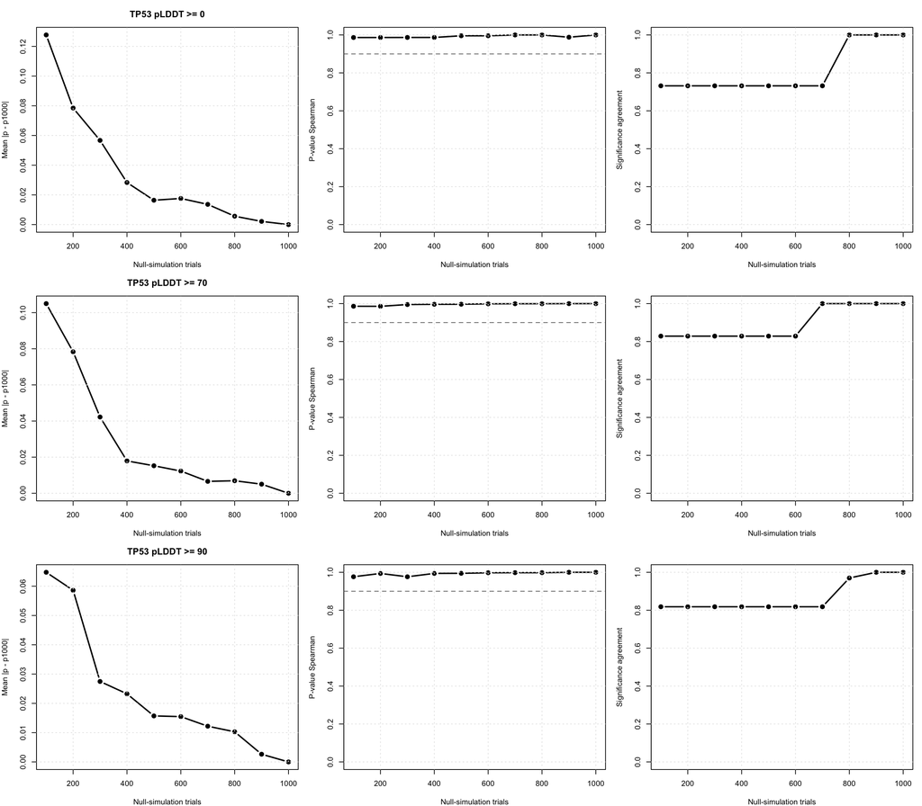

**TP53 conclusion:** the exact 1,000-trial significance sets persist from 800 trials without filtering, 700 trials at pLDDT ≥70, and 900 trials at pLDDT ≥90. The membership itself is invariant within each pLDDT stratum.

# 3 PTEN: independent mutation-rich pattern

## 3.1 PTEN experiment and retained cohort

```r
pten <- maximum_results[maximum_results$protein == "PTEN", ]
pten$coordinate_fraction <- pten$eligible_residues / pten$total_coordinate_residues
pten$event_fraction <- pten$mapped_events / pten$mapped_events[pten$plddt_threshold == 0]

display_table(
  pten[c(
    "plddt_threshold", "eligible_residues", "mapped_events", "mapped_subjects",
    "n_clusters", "n_significant", "coordinate_fraction", "event_fraction",
    "mean_best_jaccard", "reference_recovery_jaccard_0_8"
  )],
  caption = "PTEN structural-confidence sensitivity at 1,000 trials"
)
```

PTEN structural-confidence sensitivity at 1,000 trials

| plddt_threshold | eligible_residues | mapped_events | mapped_subjects | n_clusters | n_significant | coordinate_fraction | event_fraction | mean_best_jaccard | reference_recovery_jaccard_0_8 |
| --- | --- | --- | --- | --- | --- | --- | --- | --- | --- |
| 0 | 403 | 313 | 180 | 162 | 0 | 1.000 | 1.000 | 1.000 | 1.000 |
| 70 | 313 | 309 | 177 | 154 | 0 | 0.777 | 0.987 | 0.973 | 0.969 |
| 90 | 277 | 303 | 177 | 149 | 0 | 0.687 | 0.968 | 0.922 | 0.901 |

At pLDDT ≥70, PTEN retains 309 of 313 mutations and has mean cluster Jaccard 0.973. At pLDDT ≥90, it retains 303 mutations and has mean Jaccard 0.922.

## 3.2 PTEN p-value and significance convergence

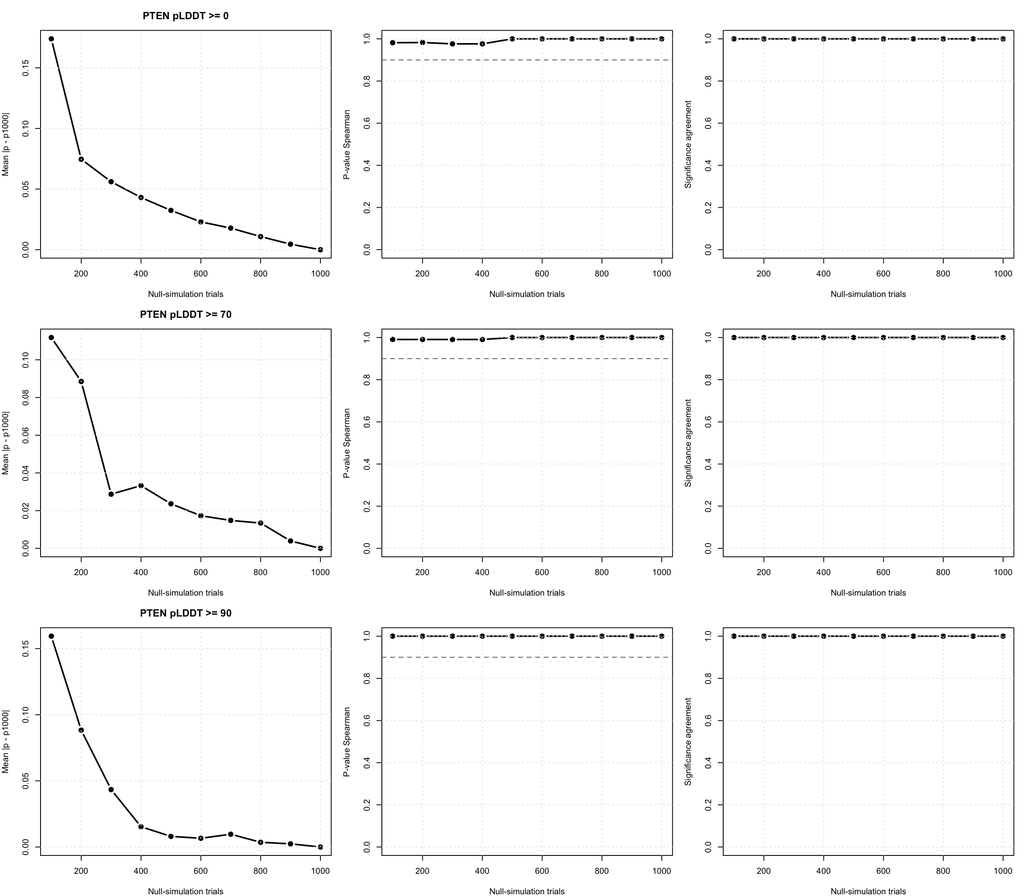

**PTEN conclusion:** membership is invariant across trial counts at each fixed threshold. PTEN is also comparatively robust to confidence filtering: mean Jaccard is 0.973 at pLDDT ≥70 and 0.922 at pLDDT ≥90. No corrected significant clusters occur in any evaluated PTEN condition. Its exact empty significance sets therefore represent trivial agreement, not positive evidence of significance convergence.

# 4 SUZ12: sparse mutation pattern

## 4.1 SUZ12 experiment and retained cohort

```r
suz12 <- maximum_results[maximum_results$protein == "SUZ12", ]
suz12$coordinate_fraction <- suz12$eligible_residues / suz12$total_coordinate_residues
suz12$event_fraction <- suz12$mapped_events / suz12$mapped_events[suz12$plddt_threshold == 0]

display_table(
  suz12[c(
    "plddt_threshold", "eligible_residues", "mapped_events", "mapped_subjects",
    "n_clusters", "n_significant", "coordinate_fraction", "event_fraction",
    "mean_best_jaccard", "reference_recovery_jaccard_0_8"
  )],
  caption = "SUZ12 structural-confidence sensitivity at 1,000 trials"
)
```

SUZ12 structural-confidence sensitivity at 1,000 trials

| plddt_threshold | eligible_residues | mapped_events | mapped_subjects | n_clusters | n_significant | coordinate_fraction | event_fraction | mean_best_jaccard | reference_recovery_jaccard_0_8 |
| --- | --- | --- | --- | --- | --- | --- | --- | --- | --- |
| 0 | 739 | 72 | 57 | 96 | 0 | 1.000 | 1.000 | 1.000 | 1.000 |
| 70 | 453 | 49 | 42 | 69 | 0 | 0.613 | 0.681 | 0.736 | 0.615 |
| 90 | 279 | 32 | 26 | 43 | 2 | 0.378 | 0.444 | 0.455 | 0.323 |

## 4.2 SUZ12 trial convergence

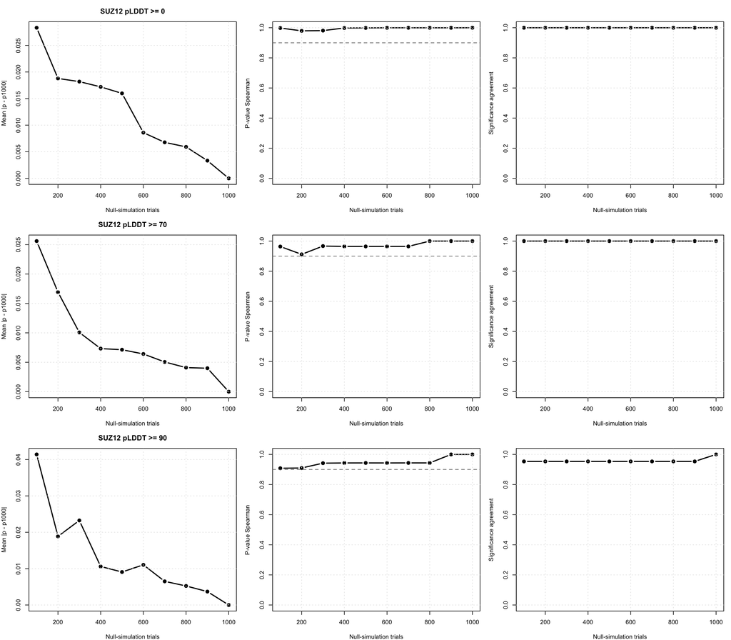

**SUZ12 conclusion:** within-threshold membership is exact across trial counts. The pLDDT ≥90 condition has a much lower mean Jaccard than the unfiltered reference and first matches the final significance set only at the 1,000-trial endpoint, so its statistical stability remains unresolved.

# 5 EZH2: sparse mutation pattern

## 5.1 EZH2 experiment and retained cohort

```r
ezh2 <- maximum_results[maximum_results$protein == "EZH2", ]
ezh2$coordinate_fraction <- ezh2$eligible_residues / ezh2$total_coordinate_residues
ezh2$event_fraction <- ezh2$mapped_events / ezh2$mapped_events[ezh2$plddt_threshold == 0]

display_table(
  ezh2[c(
    "plddt_threshold", "eligible_residues", "mapped_events", "mapped_subjects",
    "n_clusters", "n_significant", "coordinate_fraction", "event_fraction",
    "mean_best_jaccard", "reference_recovery_jaccard_0_8"
  )],
  caption = "EZH2 structural-confidence sensitivity at 1,000 trials"
)
```

EZH2 structural-confidence sensitivity at 1,000 trials

| plddt_threshold | eligible_residues | mapped_events | mapped_subjects | n_clusters | n_significant | coordinate_fraction | event_fraction | mean_best_jaccard | reference_recovery_jaccard_0_8 |
| --- | --- | --- | --- | --- | --- | --- | --- | --- | --- |
| 0 | 746 | 95 | 74 | 110 | 0 | 1.000 | 1.000 | 1.000 | 1.000 |
| 70 | 513 | 77 | 62 | 82 | 25 | 0.688 | 0.811 | 0.775 | 0.645 |
| 90 | 326 | 42 | 38 | 45 | 9 | 0.437 | 0.442 | 0.380 | 0.200 |

## 5.2 EZH2 trial convergence

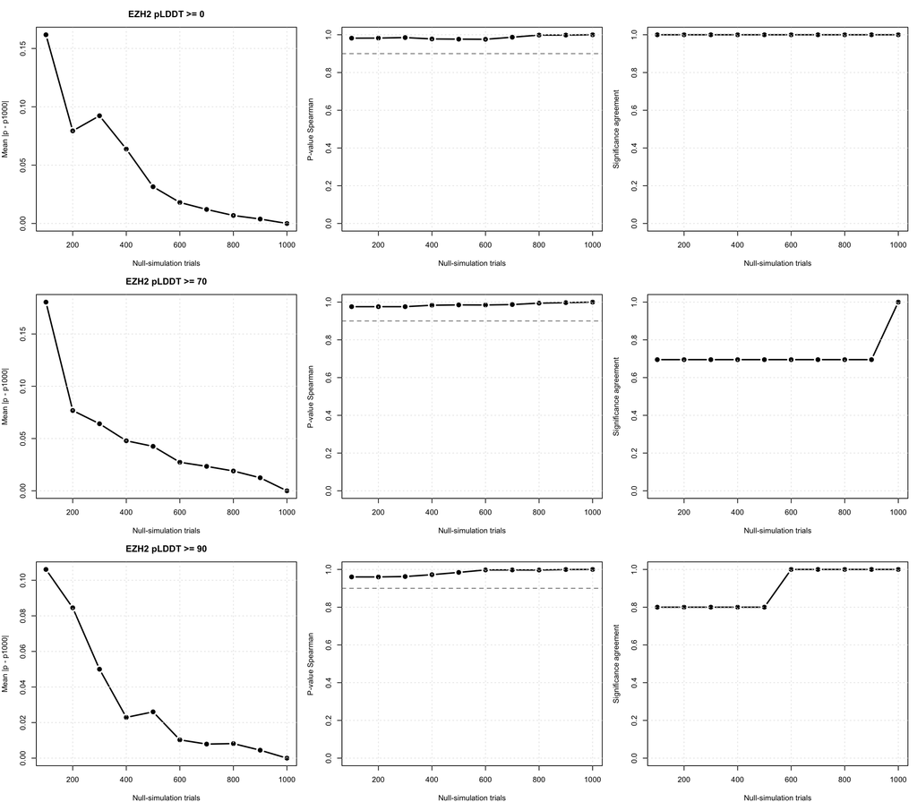

**EZH2 conclusion:** within-threshold membership is exact across trial counts. The pLDDT ≥70 significance set first equals the final result only at the 1,000-trial endpoint and therefore requires additional trials. The pLDDT ≥90 set persists from 600 trials, but it represents a substantially reduced event cohort.

# 6 LEF1: sparse mutation pattern

## 6.1 LEF1 experiment and retained cohort

```r
lef1 <- maximum_results[maximum_results$protein == "LEF1", ]
lef1$coordinate_fraction <- lef1$eligible_residues / lef1$total_coordinate_residues
lef1$event_fraction <- lef1$mapped_events / lef1$mapped_events[lef1$plddt_threshold == 0]

display_table(
  lef1[c(
    "plddt_threshold", "eligible_residues", "mapped_events", "mapped_subjects",
    "n_clusters", "n_significant", "coordinate_fraction", "event_fraction",
    "mean_best_jaccard", "reference_recovery_jaccard_0_8"
  )],
  caption = "LEF1 structural-confidence sensitivity at 1,000 trials"
)
```

LEF1 structural-confidence sensitivity at 1,000 trials

| plddt_threshold | eligible_residues | mapped_events | mapped_subjects | n_clusters | n_significant | coordinate_fraction | event_fraction | mean_best_jaccard | reference_recovery_jaccard_0_8 |
| --- | --- | --- | --- | --- | --- | --- | --- | --- | --- |
| 0 | 399 | 50 | 38 | 50 | 9 | 1.000 | 1.00 | 1.000 | 1.00 |
| 70 | 84 | 27 | 22 | 24 | 6 | 0.211 | 0.54 | 0.511 | 0.42 |
| 90 | 63 | 26 | 21 | 23 | 1 | 0.158 | 0.52 | 0.484 | 0.42 |

## 6.2 LEF1 trial convergence

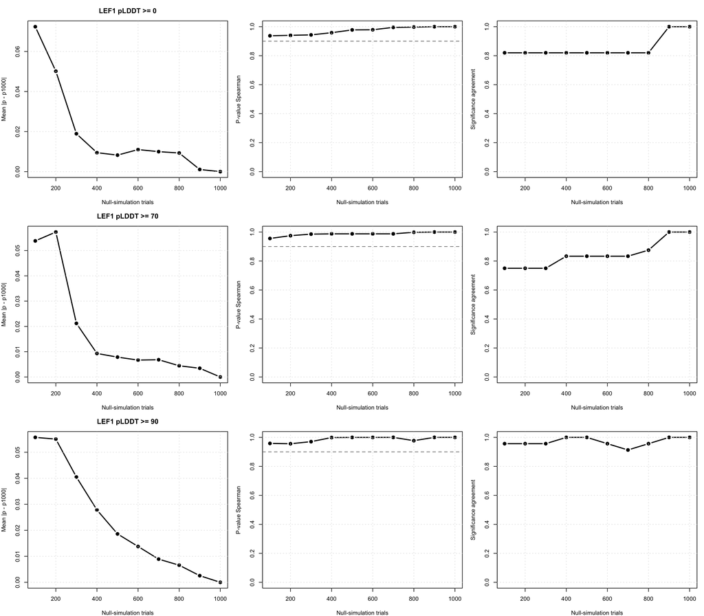

**LEF1 conclusion:** candidate membership is invariant across trial counts at each threshold, and all three 1,000-trial significance sets persist from 900 trials. The unfiltered analysis contains nine significant candidates, compared with six at pLDDT ≥70 and one at pLDDT ≥90. Confidence filtering changes the cluster landscape substantially (mean Jaccard 0.511 at ≥70 and 0.484 at ≥90) because only 27 and 26 of the original 50 events remain. The convergence result is therefore encouraging within each threshold, but filtered and unfiltered LEF1 results should be interpreted as different mutation cohorts.

# 7 Cross-protein interpretation

## 7.1 Interactive cluster stability explorer

Use the controls below to compare the strongest candidate clusters for each protein and pLDDT threshold. The matrix tracks corrected joint p-values across trial counts. Its rows do not change within a pLDDT threshold because observed cluster construction is deterministic; changes in color show Monte Carlo p-value convergence. Clicking a cell links that candidate to its best residue-overlap match at pLDDT 0, 70, and 90, revealing how structural filtering changes cluster membership. The residue-track comparison uses the 1,000-trial candidate sets, and the matrix can display up to the 40 strongest candidates ranked at 1,000 trials.

Protein Matrix pLDDT Selected trial Clusters shown

Cell color is the corrected joint p-value. Rows are residue-defined candidate clusters; click a cell to inspect that cluster and its best residue-overlap match at every pLDDT threshold.

p ≤ 0.01 p ≤ 0.05 p ≤ 0.10 p ≤ 0.25 p ≤ 0.50 p > 0.50

Best-matching residue set across pLDDT thresholds

Tracks use the 1,000-trial candidate sets. Jaccard measures residue overlap with the selected matrix row.

## 7.2 Cluster membership sensitivity

This figure puts all proteins on the same scale. Within each threshold, the line is flat across trial counts because cluster construction precedes null calibration. Differences between pLDDT lines quantify structural-filtering sensitivity.

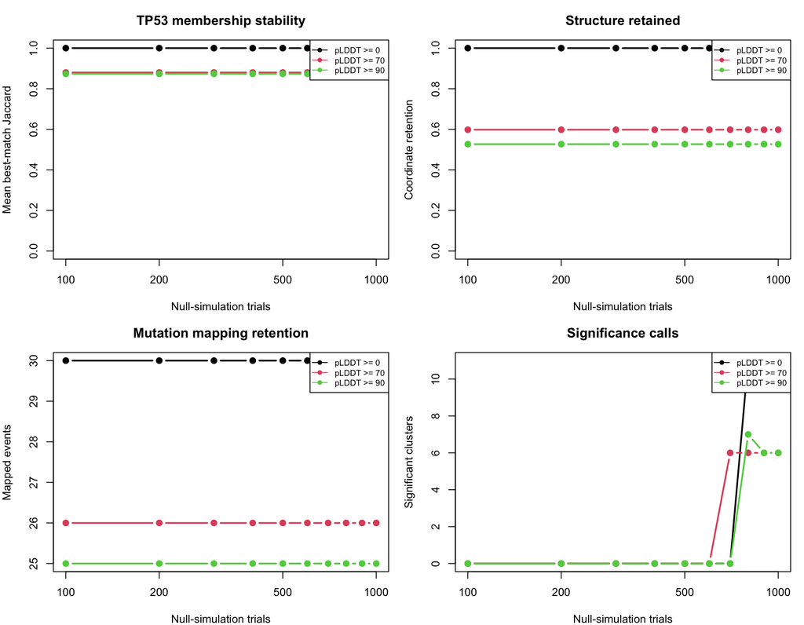

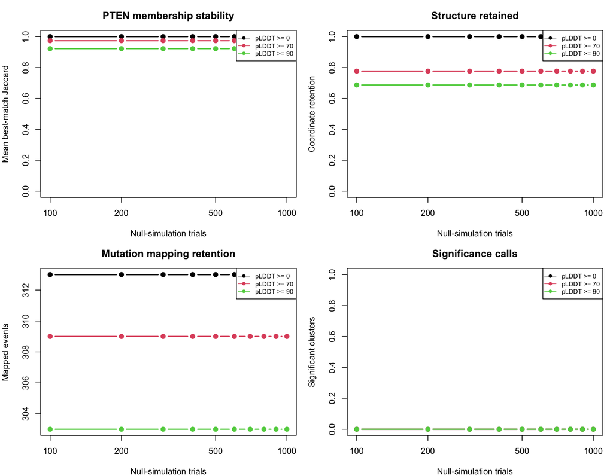

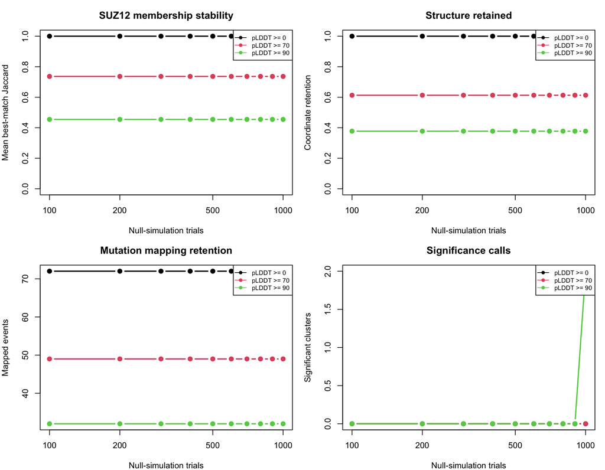

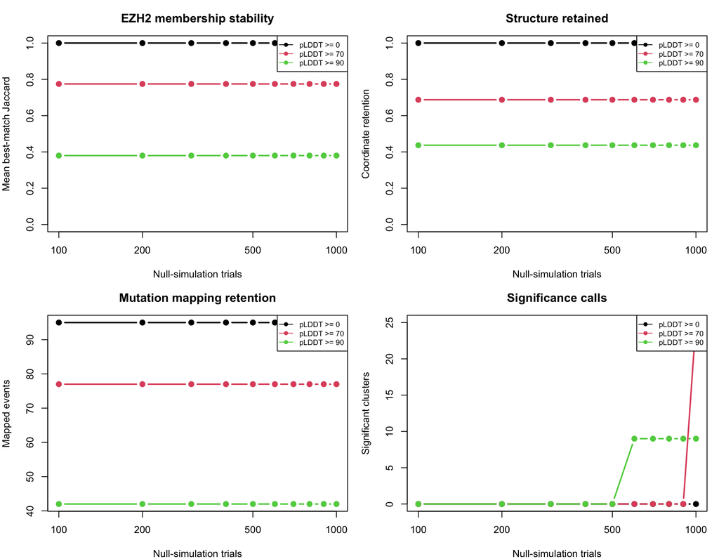

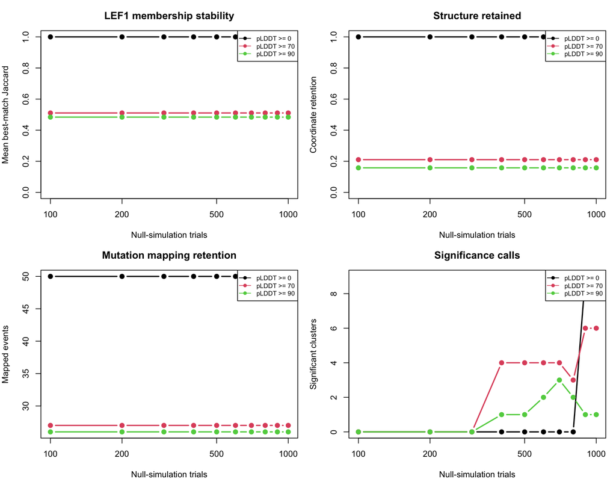

## 7.3 P-value rank and significance-set convergence

Spearman correlation measures whether clusters retain the same p-value ranking as the 1,000-trial result at the same pLDDT. Exact significance-set matching is stricter: every corrected significant cluster must agree.

```r
earliest_display <- earliest
names(earliest_display) <- c(
  "Protein", "pLDDT", "Earliest persistent exact match",
  "Significant clusters at 1,000", "Interpretation"
)
display_table(earliest_display)
```

| Protein | pLDDT | Earliest persistent exact match | Significant clusters at 1,000 | Interpretation |
| --- | --- | --- | --- | --- |
| EZH2 | 0 | 100 | 0 | Trivial agreement: no significant clusters in the 1,000-trial reference |
| EZH2 | 70 | 1000 | 25 | First trial count whose significance set matches 1,000 trials and remains matched |
| EZH2 | 90 | 600 | 9 | First trial count whose significance set matches 1,000 trials and remains matched |
| LEF1 | 0 | 900 | 9 | First trial count whose significance set matches 1,000 trials and remains matched |
| LEF1 | 70 | 900 | 6 | First trial count whose significance set matches 1,000 trials and remains matched |
| LEF1 | 90 | 900 | 1 | First trial count whose significance set matches 1,000 trials and remains matched |
| PTEN | 0 | 100 | 0 | Trivial agreement: no significant clusters in the 1,000-trial reference |
| PTEN | 70 | 100 | 0 | Trivial agreement: no significant clusters in the 1,000-trial reference |
| PTEN | 90 | 100 | 0 | Trivial agreement: no significant clusters in the 1,000-trial reference |
| SUZ12 | 0 | 100 | 0 | Trivial agreement: no significant clusters in the 1,000-trial reference |
| SUZ12 | 70 | 100 | 0 | Trivial agreement: no significant clusters in the 1,000-trial reference |
| SUZ12 | 90 | 1000 | 2 | First trial count whose significance set matches 1,000 trials and remains matched |
| TP53 | 0 | 800 | 11 | First trial count whose significance set matches 1,000 trials and remains matched |
| TP53 | 70 | 700 | 6 | First trial count whose significance set matches 1,000 trials and remains matched |
| TP53 | 90 | 900 | 6 | First trial count whose significance set matches 1,000 trials and remains matched |

A match first reached at exactly 1,000 trials cannot demonstrate persistence, because no later evaluated trial count exists. Conditions with zero significant clusters have trivial agreement on an empty set rather than positive evidence of statistical convergence.

## 7.4 Do p-values decrease as trials increase?

Not necessarily. For `B` evaluation simulations and `b` null outcomes at least as extreme as the observed cluster, the empirical estimate is approximately `p = (1 + b) / (1 + B)`. Adding simulations increases both the possible denominator and the opportunity to observe additional extreme null outcomes. An individual p-value can therefore decrease, increase, or remain unchanged.

What reliably improves is **resolution**. GRIN3D reserves half of each run for evaluation, so the smallest attainable evaluation p-value becomes progressively smaller as the total trial count rises.

```r
resolution <- unique(run_metrics[c(
  "n_sim", "n_evaluation", "minimum_empirical_p"
)])
resolution <- resolution[order(resolution$n_sim), ]
names(resolution) <- c("Total trials", "Evaluation trials", "Minimum empirical p")
display_table(resolution, digits = 5L,
              caption = "Monte Carlo resolution available at each trial count")
```

Monte Carlo resolution available at each trial count

| Total trials | Evaluation trials | Minimum empirical p |
| --- | --- | --- |
| 100 | 50 | 0.01961 |
| 200 | 100 | 0.00990 |
| 300 | 150 | 0.00662 |
| 400 | 200 | 0.00498 |
| 500 | 250 | 0.00398 |
| 600 | 300 | 0.00332 |
| 700 | 350 | 0.00285 |
| 800 | 400 | 0.00249 |
| 900 | 450 | 0.00222 |
| 1000 | 500 | 0.00200 |

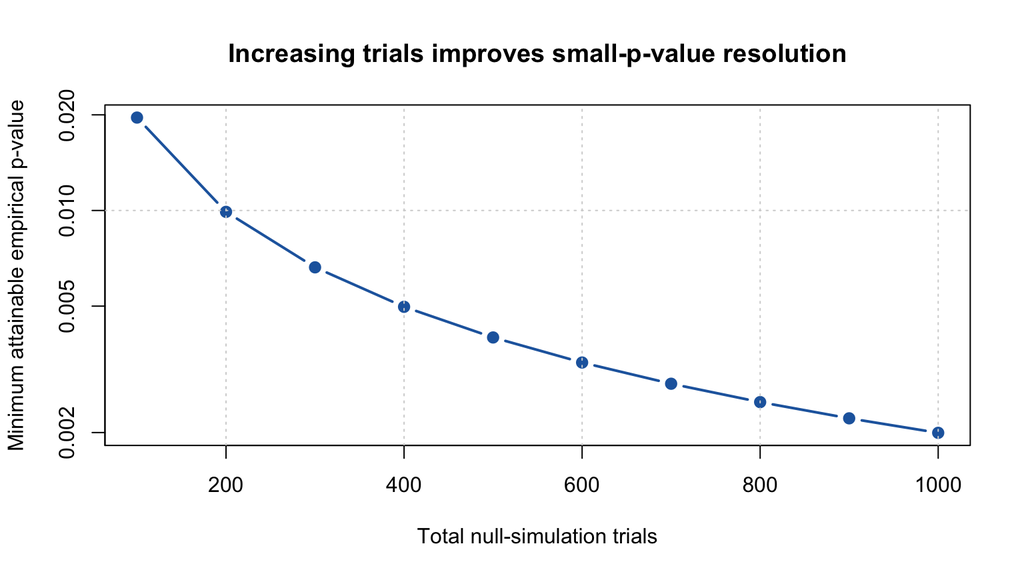

```r
plot(
  resolution$`Total trials`, resolution$`Minimum empirical p`,
  type = "b", pch = 19, lwd = 2, col = "#2166AC", log = "y",
  xlab = "Total null-simulation trials",
  ylab = "Minimum attainable empirical p-value",
  main = "Increasing trials improves small-p-value resolution"
)
grid()
```

The next cell directly compares every candidate cluster’s 100-trial p-value with its p-value in the 1,000-trial reference at the same protein and pLDDT. This demonstrates that decreasing p-values are common—especially for the strongest clusters—but are not a mathematical requirement.

```r
initial_pvalues <- pvalue_clusters[pvalue_clusters$n_sim == 100, ]
delta <- initial_pvalues$reference_p_any_joint - initial_pvalues$p_any_joint
initial_pvalues$direction <- ifelse(
  delta < -1e-12, "Lower at 1,000",
  ifelse(delta > 1e-12, "Higher at 1,000", "Unchanged")
)

direction_groups <- split(
  initial_pvalues,
  interaction(initial_pvalues$protein, initial_pvalues$plddt_threshold, drop = TRUE)
)
direction_summary <- do.call(rbind, lapply(direction_groups, function(z) {
  counts <- table(factor(
    z$direction,
    levels = c("Lower at 1,000", "Higher at 1,000", "Unchanged")
  ))
  data.frame(
    Protein = z$protein[[1L]], pLDDT = z$plddt_threshold[[1L]],
    `Lower at 1,000` = unname(counts[[1L]]),
    `Higher at 1,000` = unname(counts[[2L]]),
    Unchanged = unname(counts[[3L]]),
    `Total clusters` = nrow(z), check.names = FALSE
  )
}))
direction_summary <- direction_summary[
  order(match(direction_summary$Protein, c("TP53", "PTEN", "SUZ12", "EZH2", "LEF1")),
        direction_summary$pLDDT),
]
display_table(direction_summary,
              caption = "Direction of p-value change from 100 to 1,000 trials")
```

Direction of p-value change from 100 to 1,000 trials

| Protein | pLDDT | Lower at 1,000 | Higher at 1,000 | Unchanged | Total clusters |
| --- | --- | --- | --- | --- | --- |
| TP53 | 0 | 19 | 0 | 22 | 41 |
| TP53 | 70 | 15 | 3 | 17 | 35 |
| TP53 | 90 | 16 | 0 | 17 | 33 |
| PTEN | 0 | 43 | 0 | 119 | 162 |
| PTEN | 70 | 40 | 0 | 114 | 154 |
| PTEN | 90 | 39 | 0 | 110 | 149 |
| SUZ12 | 0 | 17 | 5 | 74 | 96 |
| SUZ12 | 70 | 12 | 0 | 57 | 69 |
| SUZ12 | 90 | 13 | 0 | 30 | 43 |
| EZH2 | 0 | 45 | 1 | 64 | 110 |
| EZH2 | 70 | 36 | 0 | 46 | 82 |
| EZH2 | 90 | 19 | 2 | 24 | 45 |
| LEF1 | 0 | 19 | 0 | 31 | 50 |
| LEF1 | 70 | 10 | 1 | 13 | 24 |
| LEF1 | 90 | 9 | 2 | 12 | 23 |

```r
overall_direction <- table(factor(
  initial_pvalues$direction,
  levels = c("Lower at 1,000", "Higher at 1,000", "Unchanged")
))
significant_reference <- initial_pvalues[initial_pvalues$reference_significant_any, ]
significant_direction <- table(factor(
  significant_reference$direction,
  levels = c("Lower at 1,000", "Higher at 1,000", "Unchanged")
))

pvalue_direction_conclusion <- data.frame(
  Comparison = c("All candidate clusters", "Significant in the 1,000-trial reference"),
  `Lower at 1,000` = c(overall_direction[[1L]], significant_direction[[1L]]),
  `Higher at 1,000` = c(overall_direction[[2L]], significant_direction[[2L]]),
  Unchanged = c(overall_direction[[3L]], significant_direction[[3L]]),
  check.names = FALSE
)
display_table(pvalue_direction_conclusion)
```

| Comparison | Lower at 1,000 | Higher at 1,000 | Unchanged |
| --- | --- | --- | --- |
| All candidate clusters | 352 | 14 | 750 |
| Significant in the 1,000-trial reference | 75 | 0 | 0 |

Across all conditions, 352 cluster estimates were lower at 1,000 trials, 14 were higher, and 750 were unchanged. All 75 cluster instances significant in their 1,000-trial reference had lower p-values than at 100 trials. Thus the strongest signals benefited from added resolution, while the full collection demonstrates that monotonic reduction is not a general rule.

**Interpretation.** Increasing trials refines the null estimate and permits smaller measurable p-values. It does not create new observed clusters, and it does not guarantee that every p-value moves downward. The relevant objective is convergence of p-values and significance decisions, not monotonic reduction.

# 8 PAE support for three-dimensional clusters

Predicted aligned error (PAE) addresses a different uncertainty than pLDDT. pLDDT describes local confidence at one residue, whereas PAE describes the confidence in the relative placement of a pair of residues. For each multi-residue candidate, this analysis conservatively symmetrizes AlphaFold’s directional matrix using `max(PAE[i,j], PAE[j,i])` and reports the median, 90th percentile, maximum, and fraction of within-cluster pairs at or below 10 Å. A cluster is marked **PAE-supported** when at least 80% of its pairs meet that cutoff. Singleton candidates have no pairwise PAE classification.

These values are a structural-confidence layer. They do not change candidate membership, null simulations, corrected p-values, or statistical significance.

PAE support at 1,000 null-simulation trials

| Protein | pLDDT | Multi-residue clusters | PAE-supported | Supported fraction | Significant | Significant and PAE-supported |
| --- | --- | --- | --- | --- | --- | --- |
| TP53 | 0 | 34 | 25 | 0.735 | 11 | 7 |
| TP53 | 70 | 29 | 28 | 0.966 | 6 | 6 |
| TP53 | 90 | 27 | 27 | 1.000 | 6 | 6 |
| PTEN | 0 | 130 | 121 | 0.931 | 0 | 0 |
| PTEN | 70 | 122 | 121 | 0.992 | 0 | 0 |
| PTEN | 90 | 118 | 118 | 1.000 | 0 | 0 |
| SUZ12 | 0 | 88 | 45 | 0.511 | 0 | 0 |
| SUZ12 | 70 | 65 | 52 | 0.800 | 0 | 0 |
| SUZ12 | 90 | 40 | 38 | 0.950 | 2 | 2 |
| EZH2 | 0 | 93 | 59 | 0.634 | 0 | 0 |
| EZH2 | 70 | 67 | 63 | 0.940 | 25 | 21 |
| EZH2 | 90 | 37 | 35 | 0.946 | 9 | 8 |
| LEF1 | 0 | 42 | 30 | 0.714 | 9 | 6 |
| LEF1 | 70 | 21 | 21 | 1.000 | 6 | 6 |
| LEF1 | 90 | 20 | 20 | 1.000 | 1 | 1 |

The unfiltered results provide the broadest structural stress test. PAE support is lower there for TP53, SUZ12, EZH2, and LEF1 because the candidate set can join residues whose relative placement is uncertain. Increasing the pLDDT threshold generally raises the PAE-supported fraction, but it also changes the eligible coordinates and mutation cohort. Therefore, improved PAE support after filtering should not be interpreted as the same clusters becoming more certain.

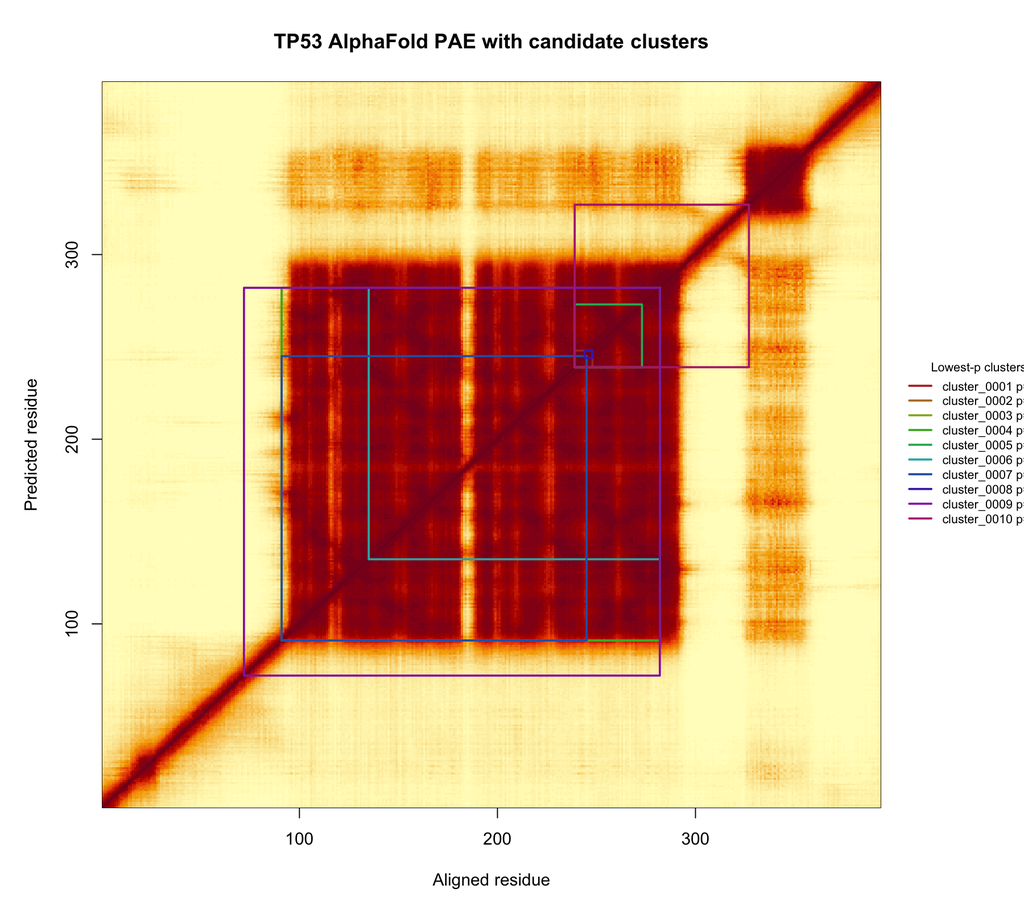

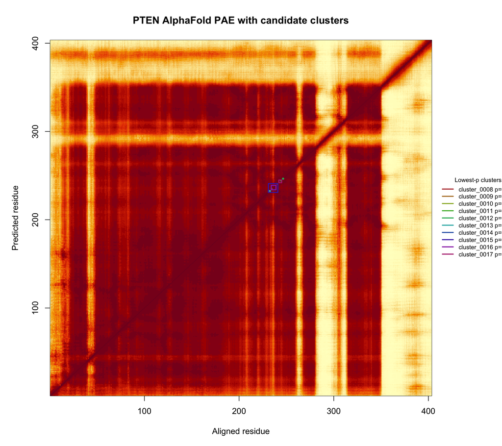

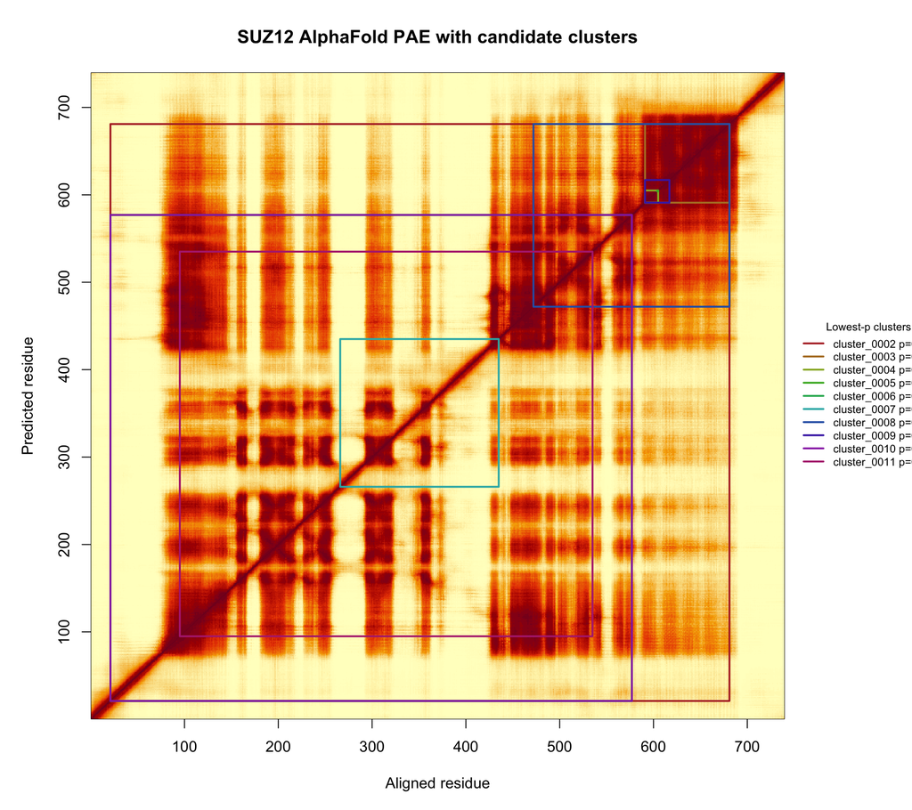

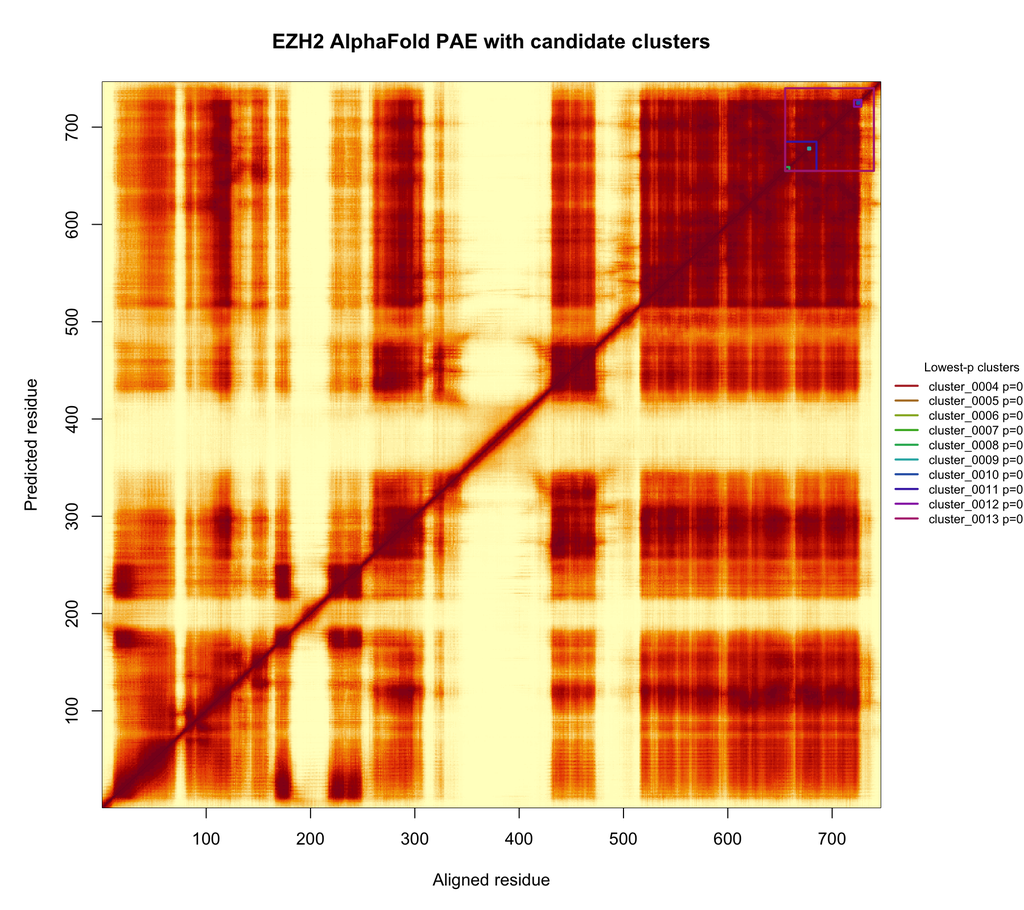

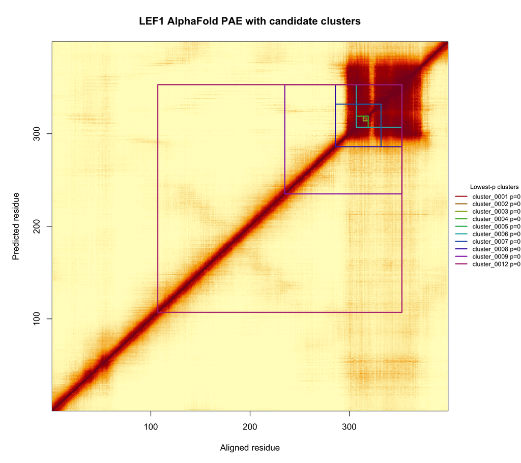

The colored boxes mark the ten lowest corrected-p candidates in each protein’s unfiltered 1,000-trial analysis. A compact box over a low-PAE region supports the predicted relative geometry; boxes spanning high-PAE regions warrant a more cautious 3D interpretation. The saved cutoff-sensitivity table repeats the classification at 5, 10, and 15 Å so the 10 Å choice is not treated as a unique biological truth.

**Interpretation boundary.** A statistically significant but PAE-uncertain cluster remains a statistical hotspot; its specific 3D arrangement is uncertain. Conversely, PAE support does not make a nonsignificant candidate statistically significant.

# 9 Recommendations

1. Treat observed cluster membership as reproducible candidate generation when the structural input and pLDDT threshold are fixed.
2. Report empirical p-values separately from cluster membership. Trial count changes Monte Carlo resolution even when cluster residues are unchanged.
3. Use pLDDT ≥70 as a sensitivity analysis and report retained residues, mutations, and subjects alongside every filtered result.
4. Use pLDDT ≥90 as a stringent stress test, not an automatically preferred primary analysis.
5. Do not treat a significance set that appears for the first time at 1,000 trials as converged. Extend those conditions beyond 1,000 trials.
6. Repeat final analyses with independent random seeds to measure Monte Carlo variability; the present nested fixed-seed runs measure resolution behavior.
7. Keep biological annotation as a separate evidence layer from statistical significance.
8. Report PAE support next to every multi-residue 3D claim and review results across the 5, 10, and 15 Å sensitivity cutoffs.

**Handoff summary.** The prototype is ready for documented exploratory hotspot discovery and sensitivity evaluation. The evidence does not yet support treating every corrected significance call as final, especially where convergence is first observed only at the 1,000-trial endpoint or confidence filtering removes a large portion of the event cohort.

# 10 Reproduction and source files

The simulation results are already saved. To regenerate only this notebook:

```bash
conda run -n kids26-team13 Rscript -e \
  'rmarkdown::render("analysis/mutation_plddt_trials/mutation_plddt_trials_report.Rmd")'
```

Primary files used by the notebook:

- `configurations.csv`: declared experiment grid and input paths;
- `results/summary/run_metrics.csv`: one row per configuration;
- `results/summary/trial_convergence_metrics.csv`: p-value convergence metrics;
- `results/summary/cluster_pvalue_convergence.csv`: cluster-level p-value trajectories;
- `results/summary/earliest_significance_convergence.csv`: exact-set stability;
- `results/summary/cluster_pae_support.csv`: cluster-level PAE metrics;
- `results/summary/pae_cutoff_sensitivity.csv`: PAE support at 5, 10, and 15 Å;
- `results/figures/`: precomputed overlap and convergence figures.

TP53 structural-confidence source:

- AlphaFold DB entry: https://alphafold.ebi.ac.uk/entry/P04637
- AlphaFold confidence documentation: https://alphafold.ebi.ac.uk/faq
- Local model: `examples/TP53_mutations/input_files/AF-P04637-F1-model_v6.pdb`
- Local metadata: `examples/TP53_mutations/input_files/alphafold_P04637_metadata.json`

PTEN structural-confidence source:

- AlphaFold DB accession: `AF-P60484-F1-model_v6`
- Local model: `examples/PTEN_CNA/input_files/AF-P60484-F1-model_v6.pdb`
- Mutation provenance: `examples/PTEN_mutations/input_files/mutation_input_provenance.txt`

LEF1 structural-confidence source:

- UniProt accession: `Q9UJU2` (399-residue canonical protein)
- RefSeq protein: `NP_057353.1`
- Local model: `examples/LEF1_mutations/input_files/AF-Q9UJU2-F1-model_v6.pdb`
- Mutation provenance: `examples/LEF1_mutations/input_files/mutation_input_provenance.txt`